# Finding Fake Traffic Tickets in CT State Police Data

A decidedly old-school approach

R

Anomaly Detection

Author

Gio Circo, Ph.D.

Published

March 7, 2025

## Fake Tickets Galore

In 2022 news broke that Connecticut State Police officers had been likely submitting tens of thousands of fake traffic tickets. What started from a [report by CT Insider](https://www.ctinsider.com/news/article/CT-troopers-fabricated-tickets-17393339.php) about 4 officers expanded to an audit that implicated dozens more officers in the scandal.

Before I start, this is more of an academic exercise. I actually think the approach that the folks who did the audit is probably the best way and simplest way. In their case they found fake tickets by counting up the number of stops which didn’t have a matching citation in the system. For this example we’re going to rely only on the raw data which is publically available.

## Working on the outside

My hypothesis for the fake ticketing was that officers wanted to quickly pad their activity logs with fake stops. Because creating a stop log requires filling out a standardized form, I assumed that these officers would do it as quickly and as lazily as possible. I can imagine this looking like an officer at the end of their shift padding out activity with a bunch of zero-effort fake stops. Relying on this hunch, I figured I could detect unusual officer behavior by finding those whose distribution of stop times looked much different than the average officer. Humans are actually [quite bad](https://journals.plos.org/plosone/article?id=10.1371/journal.pone.0041531) at generating “random” numbers. In order to pad out a shift, there would probably be a lot of stops with very short times.

### The Data

The data for this comes from Connecticut’s [Racial Profiling Prohibition Project](http://trafficstops.ctdata.org/) data portal. These contain data on all traffic stops conducted by local and state police, which have information on the time, date, reason for the stop, and some basic demographic information on the driver. For this analysis I use the data from 2018, and focus on unique stops involving only officers from the Connecticut State Police.

Unfortunately for me, the publicly available data doesn’t directly disclose the length of the stop. There is a variable `InterventionDurationCode` which only reports the length of the stop between 3 bins: `(0-15, 16-30, 30+)`. For my purposes this is far too coarse of a measure to distinguish abnormal stop lengths. However, as an analog, I figured I could instead compute the time interval *between* stops. That is, the interval in time between when one stop begins and the next stop begins. This gives us an indirect way of measuring how long a stop took before the next stop was initiated:

$$interval= time_{stop2} - time_{stop_1}$$

So if we had two stops, with one at `16:31:31` and one at `16:40:15`, the *interval* would be about 8.7 minutes. As an example, this would look like:

```
          ID       Troop Violation_Type       Date     Time Duration Interval
1 1000001884 CSP Troop E  STC Violation 2018-01-07 16:31:31     <NA>       NA
2 1000001884 CSP Troop E  Speed Related 2018-01-07 16:40:15 524 secs 8.733333
```

## Results

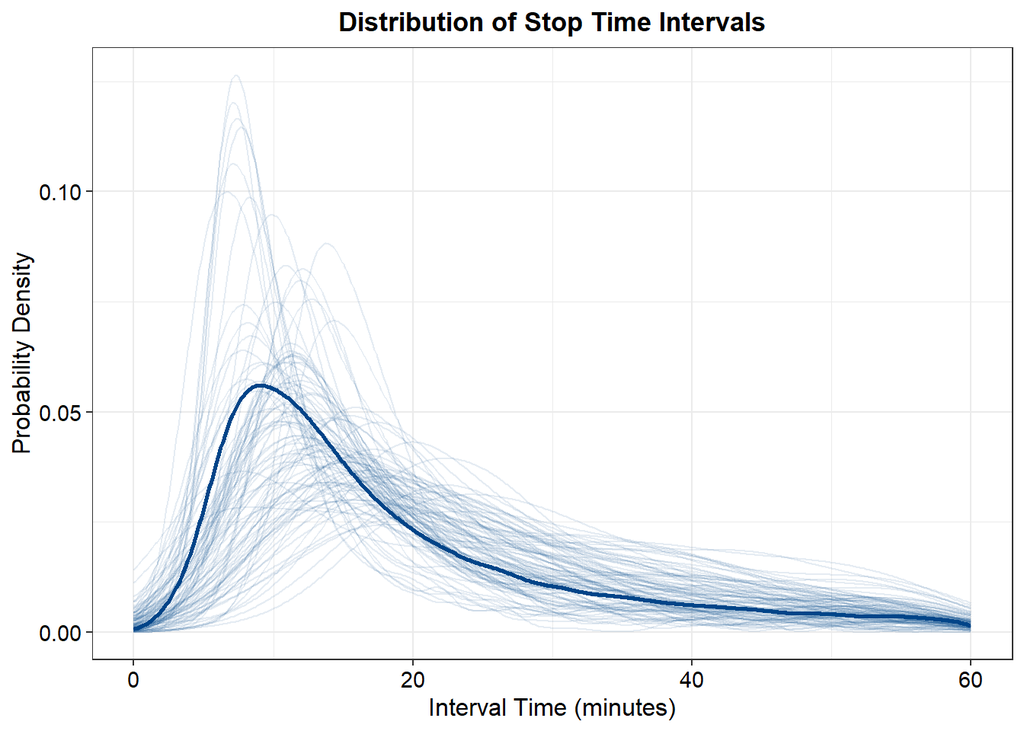

But I think an easier way to visualize this is to transform the distribution above to the *empirical cumulative density function* (ECDF) for each officer. The ECDF is actually a very useful tool for this kind of question because it makes no assumptions about the distribution of the data. Simply put, and ECDF reports the proportion of observations at or below each given interval between $[0,1]$. All we do is report the cumulative value $1/n$ for each of the $n$ data points in a distribution. This is closely related to the quantile. Such that the ECDF at 0.5 is equivalent to the median.

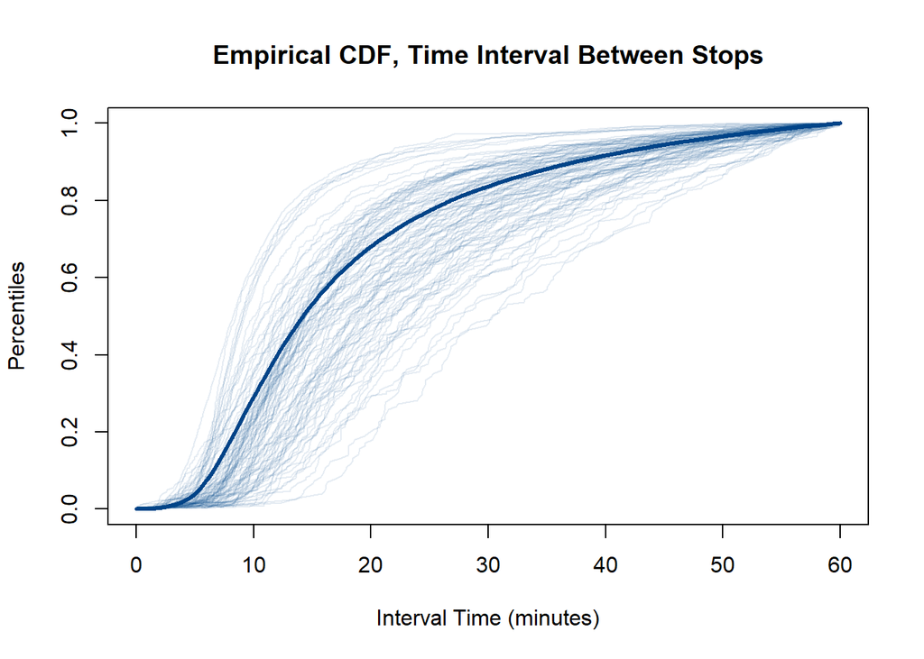

Among stop intervals under 60 minutes the median stop interval was 14 minutes. Under 10% of stops had intervals less than 6.5 minutes.

```r
# plot all ecdfs
ecdf_plot(id = unique(daily_stop_interval$officer_id),
          lwd = 3,
          main = "Empirical CDF, Time Interval Between Stops",
          xlab = "Interval Time (minutes)",
          ylab = "Percentiles",
          col = "#004488")
for(id in times$officer_id){
  ecdf_plot(id, lines=TRUE,col = alpha(rgb(0, .267, .533), .1))
}
```

### Intervals

To get intervals we do the following:

```r
# compute bands on all ecdfs, for 100 points
time_min <- min(daily_stop_interval$time_diff_min)
time_max <- max(daily_stop_interval$time_diff_min)
N_points <- 125

x_vals <- seq(time_min, time_max, length.out = N_points)


# Compute all ECDF values at each x for all officer IDs
ecdf_values <- sapply(times$officer_id, function(id) {
  ecdf_func <- ecdf(daily_stop_interval$time_diff_min[daily_stop_interval$officer_id == id])
  ecdf_func(x_vals)
})


# Compute 5th and 95th percentiles for the confidence bands
lower_band <- apply(ecdf_values, 1, function(row) quantile(row, 0.05))
upper_band <- apply(ecdf_values, 1, function(row) quantile(row, 0.95))
```

### Officer “88185785”

This officer had the shortest average interval between stops at 14.2 minutes. In fact, more than half of their stops were at intervals of 10 minutes or less. This feels incredibly fast if you consider how long it takes to pull someone over. It seems implausible that this person was conducting almost non-stop traffic stops, taking driver information, issuing a warning (I assume?), and then getting *another* stop almost immediately afterwards.

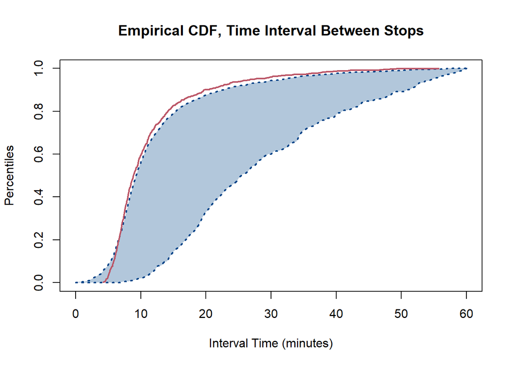

```r
officer_id = '88185785'

# Add confidence bands (shaded region)
plot.new()
plot(c(0, 60), c(0,1), col = "white",
     main = "Empirical CDF, Time Interval Between Stops",
     xlab = "Interval Time (minutes)",
     ylab = "Percentiles")
polygon(c(x_vals, rev(x_vals)), c(lower_band, rev(upper_band)),
        col = rgb(0, .267, .533, 0.3), border = NA)
lines(x_vals, lower_band, col = "#004488", lwd = 2, lty = 3)
lines(x_vals, upper_band, col = "#004488", lwd = 2, lty = 3)
ecdf_plot(officer_id, col = '#BB5566', lwd=2, lines = T)
```